# metadata_Alignment

Ian Greaves

12 September 2018

```r
library(tidyverse)
library(purrr)
```

## Alignment

### Index

Made index of the Canola genome using:

```
LOGDIR=/flush1/gre486/Canola_data/log
INPDIR=/flush1/gre486/Canola_data/raw
REFDIR=/flush1/gre486/Canola_data/reference_genome
ANODIR=/flush1/gre486/Canola_data/annotation
OUTDIR=/flush1/gre486/Canola_data/processed

STAR \
--runMode genomeGenerate \
--genomeDir ${REFDIR}/ \
--genomeFastaFiles ${REFDIR}/Brassica_napus_v4.1.chromosomes.fa \
--sjdbGTFfile ${ANODIR}/Brassica_napus.annotation_v5_exon.gtf \
--sjdbOverhang 149
```

### Alignment with STAR

```
INPDIR=/flush1/gre486/Canola_data/raw
REFDIR=/flush1/gre486/Canola_data/reference_genome
ANODIR=/flush1/gre486/Canola_data/annotation
OUTDIR=/flush1/gre486/Canola_data/processed/Alignment


SAMPLES=( $(cut -d " " -f 1 STARInputList.csv) );
INFILES_R1=( $(cut -d " " -f 2 STARInputList.csv) );
INFILES_R2=( $(cut -d " " -f 3 STARInputList.csv) );


if [ ! -z "$SLURM_ARRAY_TASK_ID" ]
then
    i=$SLURM_ARRAY_TASK_ID
    STAR \
    --runThreadN 8 \
    --genomeDir ${REFDIR}/ \
    --readFilesCommand zcat \
    --readFilesIn ${INPDIR}/${INFILES_R1[$i]} ${INPDIR}/${INFILES_R2[$i]} \
    --outFileNamePrefix ${OUTDIR}/${SAMPLES[$i]} \
    --outSAMstrandField intronMotif \
    --outFilterMismatchNmax 10 \
    --outSAMtype BAM SortedByCoordinate \
    --quantMode TranscriptomeSAM GeneCounts \
    --outFilterMultimapNmax 10 \
    --outSAMattrIHstart 0 \
    --outSAMmapqUnique 255 \
    --outSAMmultNmax -1 \
    --chimSegmentMin 40
else
    echo "Error: Missing array index as SLURM_ARRAY_TASK_ID"
fi
```

### Preparing metadata data for R

Input metadata with Alignment information. These files are from *.final.out from the STAR aligner. Files were first modified in bash using the below code:

```
for file in *final.out; do
sample=${file%%.*}
cat $file | grep -vE '(%$|:$)' | sed "s/ |//g" | sed "s/^ *//g" | sed '/^\s*$/d'> $sample.txt
done
```

## R-Analysis of Metadata

Inputted Metadata Alignment files from STAR. Removed white space from the parameters which may influence downstream applications

```r
data <- map_dfc(list.files(path="x:/2018_dataschool/Alignment/default/", pattern="Log.txt", full.names = TRUE), read_tsv, col_names = FALSE)
data <-data[, c(1,seq(2, ncol(data), by = 2))]

samples<-as_vector(list.files(path="x:/2018_dataschool/Alignment/default/", pattern="Log.txt"))

samples<-c("parameters",samples)
colnames(data)<-samples
data$parameters <- gsub('\\s+', '_', data$parameters)
lanes <- c()
data
```

```
## # A tibble: 19 x 34
##    parameters GarRepALog.txt GarRepBLog.txt GarRepCLog.txt GxNX0052RepALog~
##    <chr>      <chr>          <chr>          <chr>          <chr>
##  1 Started_j~ Sep 06 11:56:~ Sep 06 11:56:~ Sep 06 11:56:~ Sep 06 11:56:56
##  2 Started_m~ Sep 06 11:58:~ Sep 06 11:58:~ Sep 06 11:58:~ Sep 06 11:59:00
##  3 Finished_~ Sep 06 12:14:~ Sep 06 12:17:~ Sep 06 12:17:~ Sep 06 12:13:43
##  4 Mapping_s~ 86.63          79.00          82.83          95.44
##  5 Number_of~ 22909381       24556995       25583809       23409078
##  6 Average_i~ 300            300            300            300
##  7 Uniquely_~ 19720533       21589186       22906806       20948705
##  8 Average_m~ 296.70         296.51         296.51         295.64
##  9 Number_of~ 15455782       15425732       16006280       18996253
## 10 Number_of~ 14543235       14368502       14534481       18030208
## 11 Number_of~ 15323228       15270658       15848220       18825149
## 12 Number_of~ 106315         130877         132033         147378
## 13 Number_of~ 4633           5396           5639           4828
## 14 Number_of~ 21606          18801          20388          18898
## 15 Deletion_~ 2.50           2.60           2.56           2.91
## 16 Insertion~ 1.96           1.93           1.94           2.08
## 17 Number_of~ 1286383        1472737        1417684        1195047
## 18 Number_of~ 471348         284969         68108          38388
## 19 Number_of~ 64576          85231          112643         142247
## # ... with 29 more variables: GxNX0052RepBLog.txt <chr>,
## #   GxNX0052RepCLog.txt <chr>, GxNX1132RepALog.txt <chr>,
## #   GxNX1132RepBLog.txt <chr>, GxNX1132RepCLog.txt <chr>,
## #   NX0052RepALog.txt <chr>, NX0052RepBLog.txt <chr>,
## #   NX0052RepCLog.txt <chr>, NX0052xGRepALog.txt <chr>,
## #   NX0052xGRepBLog.txt <chr>, NX0052xGRepCLog.txt <chr>,
## #   NX1132RepALog.txt <chr>, NX1132RepBLog.txt <chr>,
## #   NX1132RepCLog.txt <chr>, NX1132xGRepALog.txt <chr>,
## #   NX1132xGRepBLog.txt <chr>, NX1132xGRepCLog.txt <chr>,
## #   SapRepALog.txt <chr>, SapRepBLog.txt <chr>, SapRepCLog.txt <chr>,
## #   SxWRepALog.txt <chr>, SxWRepBLog.txt <chr>, SxWRepCLog.txt <chr>,
## #   WesRepALog.txt <chr>, WesRepBLog.txt <chr>, WesRepCLog.txt <chr>,
## #   WxSRepALog.txt <chr>, WxSRepBLog.txt <chr>, WxSRepCLog.txt <chr>
```

Inputed metadata_seq file so I can tell which samples were run in which lane

```r
lanes <- read_csv(file = "C:/Users/gre486/DATASCHOOL/challenge/canola/doc/Metadata_seq.csv")
lanes
```

```
## # A tibble: 66 x 7
##    FILE             MACHINE        FLOWCELL   LANE  READ FILTERED INDEX
##    <chr>            <chr>          <chr>     <int> <int> <chr>    <chr>
##  1 C_4_1_10_1.fq.gz @ST-E00522:235 HCLF5CCXY     1     1 N        NGGCTTCA
##  2 C_4_1_10_2.fq.gz @ST-E00522:235 HCLF5CCXY     1     2 N        NGGCTTCA
##  3 C_4_1_11_1.fq.gz @ST-E00522:235 HCLF5CCXY     1     1 N        NGGTGGTA
##  4 C_4_1_11_2.fq.gz @ST-E00522:235 HCLF5CCXY     1     2 N        NGGTGGTA
##  5 C_4_1_1_1.fq.gz  @ST-E00522:235 HCLF5CCXY     1     1 N        NTCGTAGA
##  6 C_4_1_1_2.fq.gz  @ST-E00522:235 HCLF5CCXY     1     2 N        NTCGTAGA
##  7 C_4_1_2_1.fq.gz  @ST-E00522:235 HCLF5CCXY     1     1 N        NTCTGTCA
##  8 C_4_1_2_2.fq.gz  @ST-E00522:235 HCLF5CCXY     1     2 N        NTCTGTCA
##  9 C_4_1_3_1.fq.gz  @ST-E00522:235 HCLF5CCXY     5     1 N        GTGTTC
## 10 C_4_1_3_2.fq.gz  @ST-E00522:235 HCLF5CCXY     5     2 N        GTGTTC
## # ... with 56 more rows
```

Inputed STARInputList.csv which enables me to link sample name with original file in Metadata_seq.csv. Combine both to line machine, flowcell and lane to smaple name. I’ll use this information once I have produced a tidy dataframe from my alignment output

```r
sampleNames <- read_delim(file = "C:/Users/gre486/DATASCHOOL/challenge/canola/doc/STARInputList.csv", delim = ' ', col_names = FALSE)
sampleNames
```

```
## # A tibble: 33 x 3
##    X1         X2              X3
##    <chr>      <chr>           <chr>
##  1 SapRepA    C_4_1_1_1.fq.gz C_4_1_1_2.fq.gz
##  2 SapRepB    C_4_2_1_1.fq.gz C_4_2_1_2.fq.gz
##  3 SapRepC    C_4_3_1_1.fq.gz C_4_3_1_2.fq.gz
##  4 WesRepA    C_4_1_2_1.fq.gz C_4_1_2_2.fq.gz
##  5 WesRepB    C_4_2_2_1.fq.gz C_4_2_2_2.fq.gz
##  6 WesRepC    C_4_3_2_1.fq.gz C_4_3_2_2.fq.gz
##  7 GarRepA    C_4_1_3_1.fq.gz C_4_1_3_2.fq.gz
##  8 GarRepB    C_4_2_3_1.fq.gz C_4_2_3_2.fq.gz
##  9 GarRepC    C_4_3_3_1.fq.gz C_4_3_3_2.fq.gz
## 10 NX0052RepA C_4_1_4_1.fq.gz C_4_1_4_2.fq.gz
## # ... with 23 more rows
```

```r
sample_lanes<- na.omit(inner_join(lanes, sampleNames, by = c("FILE" = "X2")))
sample_lanes$Samples <- paste(sample_lanes$X1,"Log.txt", sep = "")
sample_lanes <- sample_lanes[,c(10,2:4)]
sample_lanes
```

```
## # A tibble: 33 x 4
##    Samples             MACHINE        FLOWCELL   LANE
##    <chr>               <chr>          <chr>     <int>
##  1 GxNX1132RepALog.txt @ST-E00522:235 HCLF5CCXY     1
##  2 NX1132xGRepALog.txt @ST-E00522:235 HCLF5CCXY     1
##  3 SapRepALog.txt      @ST-E00522:235 HCLF5CCXY     1
##  4 WesRepALog.txt      @ST-E00522:235 HCLF5CCXY     1
##  5 GarRepALog.txt      @ST-E00522:235 HCLF5CCXY     5
##  6 NX0052RepALog.txt   @ST-E00522:235 HCLF5CCXY     5
##  7 NX1132RepALog.txt   @ST-E00522:235 HCLF5CCXY     1
##  8 SxWRepALog.txt      @ST-E00522:235 HCLF5CCXY     1
##  9 WxSRepALog.txt      @ST-E00318:426 H7YGFCCXY     1
## 10 GxNX0052RepALog.txt @ST-E00522:235 HCLF5CCXY     1
## # ... with 23 more rows
```

I need to change rows and columns to make the data tidy from the alignment output. I also want to add genotype and replicate in so I can do some grouping in ggplot

```r
tidy_data <-data %>% gather(Samples, numbers, GarRepALog.txt:WxSRepCLog.txt) %>% spread(parameters, numbers)
tidy_data
```

```
## # A tibble: 33 x 20
##    Samples Average_input_r~ Average_mapped_~ Deletion_averag~ Finished_on
##    <chr>   <chr>            <chr>            <chr>            <chr>
##  1 GarRep~ 300              296.70           2.50             Sep 06 12:~
##  2 GarRep~ 300              296.51           2.60             Sep 06 12:~
##  3 GarRep~ 300              296.51           2.56             Sep 06 12:~
##  4 GxNX00~ 300              295.64           2.91             Sep 06 12:~
##  5 GxNX00~ 300              296.38           2.55             Sep 06 12:~
##  6 GxNX00~ 300              296.39           2.64             Sep 06 12:~
##  7 GxNX11~ 300              296.26           2.93             Sep 06 12:~
##  8 GxNX11~ 300              296.67           2.51             Sep 06 12:~
##  9 GxNX11~ 300              295.97           2.71             Sep 06 12:~
## 10 NX0052~ 300              296.08           2.51             Sep 06 12:~
## # ... with 23 more rows, and 15 more variables:
## #   Insertion_average_length <chr>,
## #   `Mapping_speed,_Million_of_reads_per_hour` <chr>,
## #   Number_of_chimeric_reads <chr>, Number_of_input_reads <chr>,
## #   Number_of_reads_mapped_to_multiple_loci <chr>,
## #   Number_of_reads_mapped_to_too_many_loci <chr>,
## #   `Number_of_splices:_Annotated_(sjdb)` <chr>,
## #   `Number_of_splices:_AT/AC` <chr>, `Number_of_splices:_GC/AG` <chr>,
## #   `Number_of_splices:_GT/AG` <chr>,
## #   `Number_of_splices:_Non-canonical` <chr>,
## #   `Number_of_splices:_Total` <chr>, Started_job_on <chr>,
## #   Started_mapping_on <chr>, Uniquely_mapped_reads_number <chr>
```

```r
tidy_data$genotype <-gsub( "^(.+)Rep.*" , "\\1" , tidy_data$Samples )
tidy_data$replicates <-gsub( "^.+(Rep.).*", "\\1", tidy_data$Samples)
tidy_data
```

```
## # A tibble: 33 x 22
##    Samples Average_input_r~ Average_mapped_~ Deletion_averag~ Finished_on
##    <chr>   <chr>            <chr>            <chr>            <chr>
##  1 GarRep~ 300              296.70           2.50             Sep 06 12:~
##  2 GarRep~ 300              296.51           2.60             Sep 06 12:~
##  3 GarRep~ 300              296.51           2.56             Sep 06 12:~
##  4 GxNX00~ 300              295.64           2.91             Sep 06 12:~
##  5 GxNX00~ 300              296.38           2.55             Sep 06 12:~
##  6 GxNX00~ 300              296.39           2.64             Sep 06 12:~
##  7 GxNX11~ 300              296.26           2.93             Sep 06 12:~
##  8 GxNX11~ 300              296.67           2.51             Sep 06 12:~
##  9 GxNX11~ 300              295.97           2.71             Sep 06 12:~
## 10 NX0052~ 300              296.08           2.51             Sep 06 12:~
## # ... with 23 more rows, and 17 more variables:
## #   Insertion_average_length <chr>,
## #   `Mapping_speed,_Million_of_reads_per_hour` <chr>,
## #   Number_of_chimeric_reads <chr>, Number_of_input_reads <chr>,
## #   Number_of_reads_mapped_to_multiple_loci <chr>,
## #   Number_of_reads_mapped_to_too_many_loci <chr>,
## #   `Number_of_splices:_Annotated_(sjdb)` <chr>,
## #   `Number_of_splices:_AT/AC` <chr>, `Number_of_splices:_GC/AG` <chr>,
## #   `Number_of_splices:_GT/AG` <chr>,
## #   `Number_of_splices:_Non-canonical` <chr>,
## #   `Number_of_splices:_Total` <chr>, Started_job_on <chr>,
## #   Started_mapping_on <chr>, Uniquely_mapped_reads_number <chr>,
## #   genotype <chr>, replicates <chr>
```

I now need to combine metadata from sequencing (Machine,flowcell @ lane) with metadata from alignment

```r
final_data <- left_join(tidy_data, sample_lanes, by = "Samples")
final_data
```

```
## # A tibble: 33 x 25
##    Samples Average_input_r~ Average_mapped_~ Deletion_averag~ Finished_on
##    <chr>   <chr>            <chr>            <chr>            <chr>
##  1 GarRep~ 300              296.70           2.50             Sep 06 12:~
##  2 GarRep~ 300              296.51           2.60             Sep 06 12:~
##  3 GarRep~ 300              296.51           2.56             Sep 06 12:~
##  4 GxNX00~ 300              295.64           2.91             Sep 06 12:~
##  5 GxNX00~ 300              296.38           2.55             Sep 06 12:~
##  6 GxNX00~ 300              296.39           2.64             Sep 06 12:~
##  7 GxNX11~ 300              296.26           2.93             Sep 06 12:~
##  8 GxNX11~ 300              296.67           2.51             Sep 06 12:~
##  9 GxNX11~ 300              295.97           2.71             Sep 06 12:~
## 10 NX0052~ 300              296.08           2.51             Sep 06 12:~
## # ... with 23 more rows, and 20 more variables:
## #   Insertion_average_length <chr>,
## #   `Mapping_speed,_Million_of_reads_per_hour` <chr>,
## #   Number_of_chimeric_reads <chr>, Number_of_input_reads <chr>,
## #   Number_of_reads_mapped_to_multiple_loci <chr>,
## #   Number_of_reads_mapped_to_too_many_loci <chr>,
## #   `Number_of_splices:_Annotated_(sjdb)` <chr>,
## #   `Number_of_splices:_AT/AC` <chr>, `Number_of_splices:_GC/AG` <chr>,
## #   `Number_of_splices:_GT/AG` <chr>,
## #   `Number_of_splices:_Non-canonical` <chr>,
## #   `Number_of_splices:_Total` <chr>, Started_job_on <chr>,
## #   Started_mapping_on <chr>, Uniquely_mapped_reads_number <chr>,
## #   genotype <chr>, replicates <chr>, MACHINE <chr>, FLOWCELL <chr>,
## #   LANE <int>
```

### - Visualizing Metadata

Plot total reads versus uniquely mapped reads

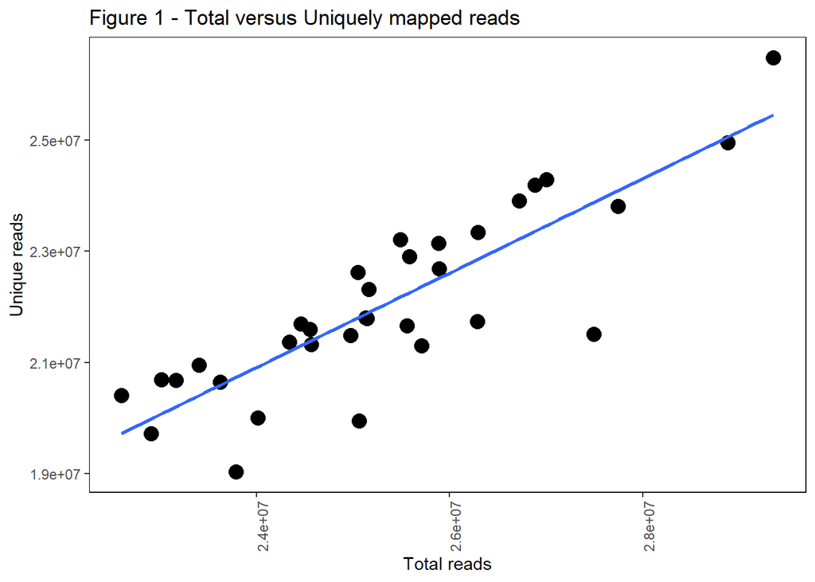

```r
ggplot(data = final_data,
       aes(x = as.numeric(Number_of_input_reads), y = as.numeric(Uniquely_mapped_reads_number))) +
  geom_point(size = 4) +
  stat_smooth(method = "lm", size = 1, se = FALSE)+
  labs(
    x = "Total reads",
    y = "Unique reads",
    title = "Figure 1 - Total versus Uniquely mapped reads"
    ) +
  theme(
    panel.grid=element_blank(),
    axis.text.x = element_text(angle=90),
    panel.background = element_rect(fill = "white",
                                    colour = "black")
  )
```

Plot total reads versus uniquely mapped to see if there is any difference between genotypes

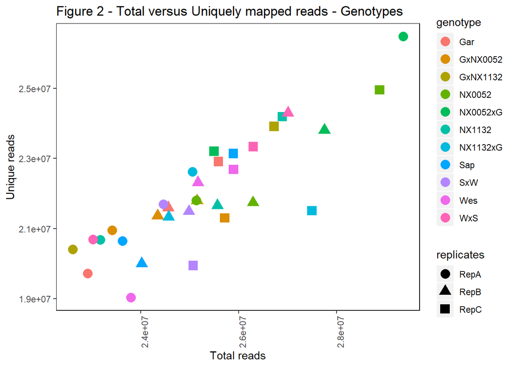

```r
ggplot(data = final_data,
       aes(x = as.numeric(Number_of_input_reads), y = as.numeric(Uniquely_mapped_reads_number), colour = genotype, shape = replicates)) +
  geom_point(size = 4) +
  labs(
    x = "Total reads",
    y = "Unique reads",
    title = "Figure 2 - Total versus Uniquely mapped reads - Genotypes",
    colour = "genotype"
  ) +
  theme(
    panel.grid=element_blank(),
    axis.text.x = element_text(angle=90),
    panel.background = element_rect(fill = "white",
                                    colour = "black")
    )
```

Split via genotype

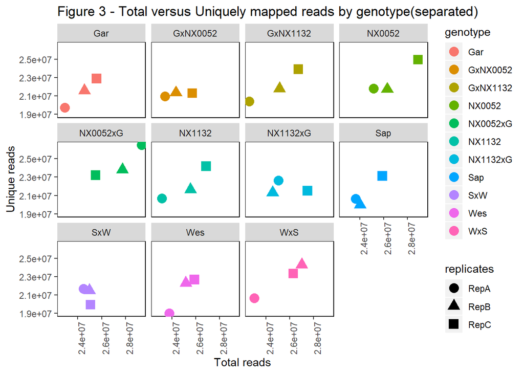

```r
ggplot(data = final_data,
       aes(x = as.numeric(Number_of_input_reads), y = as.numeric(Uniquely_mapped_reads_number), colour = genotype, shape = replicates)) +
    geom_point(size=4) +
    facet_wrap(~genotype)+
    labs(
    x = "Total reads",
    y = "Unique reads",
    title = "Figure 3 - Total versus Uniquely mapped reads by genotype(separated)",
    colour = "genotype"
  ) +
    theme(
    panel.grid=element_blank(),
    axis.text.x = element_text(angle=90),
    panel.background = element_rect(fill = "white",
                                    colour = "black")
    )
```

**CONCLUSION** No obvious difference in mapping quality between the different genotypes or replicates

### Samples were run on different lanes and machines

Ceck if downstream analyses could be affected by sequencing on different machines or lanes

```r
final_data %>%
  count(MACHINE,LANE)
```

```
## # A tibble: 5 x 3
##   MACHINE         LANE     n
##   <chr>          <int> <int>
## 1 @ST-E00318:426     1     8
## 2 @ST-E00318:426     5     1
## 3 @ST-E00522:235     1    10
## 4 @ST-E00522:235     5    13
## 5 @ST-E00522:235     6     1
```

Does lane or machine impact the mapping?

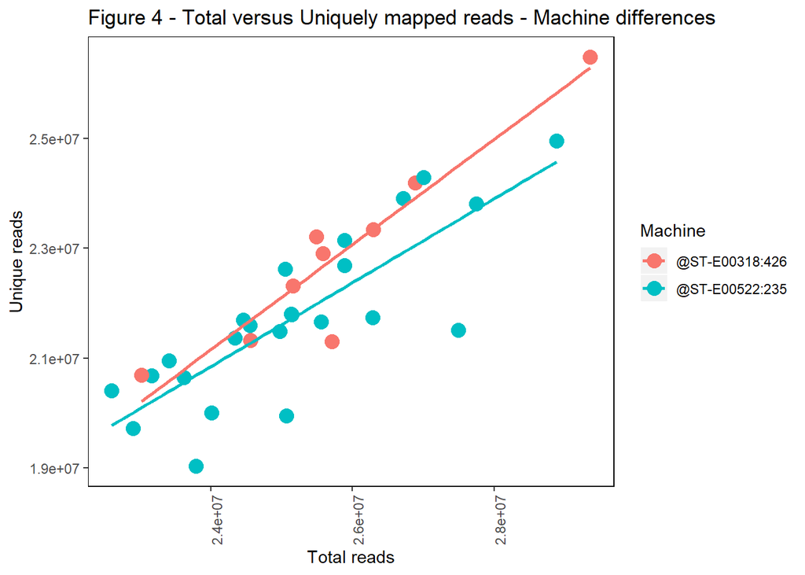

```r
ggplot(data = final_data,
       aes(x = as.numeric(Number_of_input_reads), y = as.numeric(Uniquely_mapped_reads_number), colour = MACHINE)) +
  geom_point(size=4) +
    stat_smooth(method = "lm", formula = y ~ x, size = 1, se = FALSE)+
    labs(
    x = "Total reads",
    y = "Unique reads",
    title = "Figure 4 - Total versus Uniquely mapped reads - Machine differences",
    colour = "Machine"
  ) +
    theme(
    panel.grid=element_blank(),
    axis.text.x = element_text(angle=90),
    panel.background = element_rect(fill = "white",
                                    colour = "black")
    )
```

Split Lanes by Machine

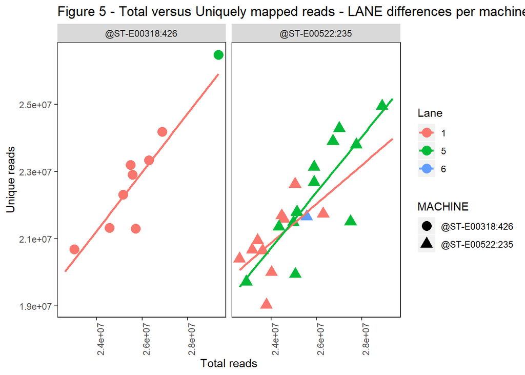

```r
ggplot(data = final_data,
       aes(x = as.numeric(Number_of_input_reads), y = as.numeric(Uniquely_mapped_reads_number), colour = as.factor(LANE), shape = MACHINE)) +
  geom_point(size=4) +
  facet_wrap(~MACHINE)+
  stat_smooth(method = "lm", size = 1, se = FALSE, fullrange=TRUE)+
    labs(
    x = "Total reads",
    y = "Unique reads",
    title = "Figure 5 - Total versus Uniquely mapped reads - LANE differences per machine",
    colour = "Lane"
  ) +
    theme(
    panel.grid=element_blank(),
    axis.text.x = element_text(angle=90),
    panel.background = element_rect(fill = "white",
                                    colour = "black")
    )
```

Are particular genotypes spread over different machines and or lanes?

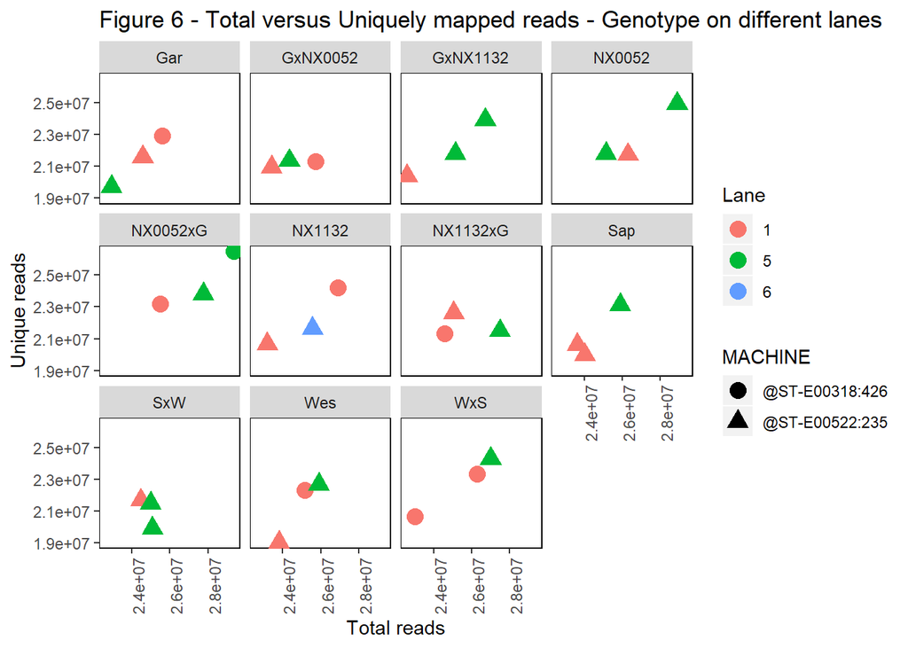

```r
ggplot(data = final_data,
       aes(x = as.numeric(Number_of_input_reads), y = as.numeric(Uniquely_mapped_reads_number), colour = as.factor(LANE), shape = MACHINE)) +
  geom_point(size=4) +
  facet_wrap(~genotype)+
    labs(
    x = "Total reads",
    y = "Unique reads",
    title = "Figure 6 - Total versus Uniquely mapped reads - Genotype on different lanes",
    colour = "Lane"
  ) +
    theme(
    panel.grid=element_blank(),
    axis.text.x = element_text(angle=90),
    panel.background = element_rect(fill = "white",
                                    colour = "black")
    )
```

**CONCLUSION** Can’t find any obvious patterns which may influence downstream gene expression analyses